# Fitting model parameters & features

# Fitting model parameters & features

The objective of this lab is to have you practice fitting a model parameters and predictor variables.

You will apply what we have learned in class. Reference code from class and from the readings may be helpful. - (Class 7.1 Code on Cross Validation, Feature Selection)[https://github.com/info370/fa17-labs/tree/master/class/7.1] - (Reading on Cross-Validation)[https://docs.google.com/document/d/1uNbgjp9CrxxwDrgLEDrf4IkJrUwZKO5TqxblWwRZkko/edit] - (Slides on Cross-Validation, Feature Selection)[https://docs.google.com/presentation/d/1znngaVSsDb-ueXCPjdwPhdCEbjuged2J37Q69w0T2_M/edit?usp=sharing]

```r
if(!require(mlbench)){install.packages("mlbench"); require(mlbench)} # common datasets to use
if(!require(caret)){install.packages("caret", dependencies = c("Depends", "Suggests")); require(caret)} # ML package and its dependencies. This will take awhile!
if(!require(dplyr)){install.packages("dplyr"); require(dplyr)}
set.seed(370)
```

## 1. Look at the data

```r
data(BostonHousing)
?BostonHousing
df_boston <- BostonHousing[, !names(BostonHousing) %in% c("chas")] # removing charles river tract b/c not numeric
head(df_boston)
```

|  | crim | zn | indus | nox | rm | age | dis | rad | tax | ptratio | b | lstat | medv |
| --- | --- | --- | --- | --- | --- | --- | --- | --- | --- | --- | --- | --- | --- |
| 1 | 0.00632 | 18 | 2.31 | 0.538 | 6.575 | 65.2 | 4.0900 | 1 | 296 | 15.3 | 396.90 | 4.98 | 24.0 |
| 2 | 0.02731 | 0 | 7.07 | 0.469 | 6.421 | 78.9 | 4.9671 | 2 | 242 | 17.8 | 396.90 | 9.14 | 21.6 |
| 3 | 0.02729 | 0 | 7.07 | 0.469 | 7.185 | 61.1 | 4.9671 | 2 | 242 | 17.8 | 392.83 | 4.03 | 34.7 |
| 4 | 0.03237 | 0 | 2.18 | 0.458 | 6.998 | 45.8 | 6.0622 | 3 | 222 | 18.7 | 394.63 | 2.94 | 33.4 |
| 5 | 0.06905 | 0 | 2.18 | 0.458 | 7.147 | 54.2 | 6.0622 | 3 | 222 | 18.7 | 396.90 | 5.33 | 36.2 |
| 6 | 0.02985 | 0 | 2.18 | 0.458 | 6.430 | 58.7 | 6.0622 | 3 | 222 | 18.7 | 394.12 | 5.21 | 28.7 |

# Feature Selection

## 2. Correlation of Features

*TODO*: Create a correlation matrix and determine if any features are highly correalted

```r
corr_matrix <- cor(df_boston[,1:12]) # correlations between all predictor vars
corr_matrix
```

```
              crim         zn      indus        nox         rm        age        dis        rad        tax    ptratio          b      lstat
crim     1.0000000 -0.2004692  0.4065834  0.4209717 -0.2192467  0.3527343 -0.3796701  0.6255051  0.5827643  0.2899456 -0.3850639  0.4556215
zn      -0.2004692  1.0000000 -0.5338282 -0.5166037  0.3119906 -0.5695373  0.6644082 -0.3119478 -0.3145633 -0.3916785  0.1755203 -0.4129946
indus    0.4065834 -0.5338282  1.0000000  0.7636514 -0.3916759  0.6447785 -0.7080270  0.5951293  0.7207602  0.3832476 -0.3569765  0.6037997
nox      0.4209717 -0.5166037  0.7636514  1.0000000 -0.3021882  0.7314701 -0.7692301  0.6114406  0.6680232  0.1889327 -0.3800506  0.5908789
rm      -0.2192467  0.3119906 -0.3916759 -0.3021882  1.0000000 -0.2402649  0.2052462 -0.2098467 -0.2920478 -0.3555015  0.1280686 -0.6138083
age      0.3527343 -0.5695373  0.6447785  0.7314701 -0.2402649  1.0000000 -0.7478805  0.4560225  0.5064556  0.2615150 -0.2735340  0.6023385
dis     -0.3796701  0.6644082 -0.7080270 -0.7692301  0.2052462 -0.7478805  1.0000000 -0.4945879 -0.5344316 -0.2324705  0.2915117 -0.4969958
rad      0.6255051 -0.3119478  0.5951293  0.6114406 -0.2098467  0.4560225 -0.4945879  1.0000000  0.9102282  0.4647412 -0.4444128  0.4886763
tax      0.5827643 -0.3145633  0.7207602  0.6680232 -0.2920478  0.5064556 -0.5344316  0.9102282  1.0000000  0.4608530 -0.4418080  0.5439934
ptratio  0.2899456 -0.3916785  0.3832476  0.1889327 -0.3555015  0.2615150 -0.2324705  0.4647412  0.4608530  1.0000000 -0.1773833  0.3740443
b       -0.3850639  0.1755203 -0.3569765 -0.3800506  0.1280686 -0.2735340  0.2915117 -0.4444128 -0.4418080 -0.1773833  1.0000000 -0.3660869
lstat    0.4556215 -0.4129946  0.6037997  0.5908789 -0.6138083  0.6023385 -0.4969958  0.4886763  0.5439934  0.3740443 -0.3660869  1.0000000
```

```r
cutoff <- 0.6 # should be higher in practice
highly_corr <- findCorrelation(corr_matrix, cutoff=cutoff)
print(colnames(df_boston)[highly_corr]) # age is highly correalted with pregnant
```

```
[1] "indus" "tax"   "nox"   "rad"   "lstat" "dis"
```

*TODO*: Determine if which features are highly correlated

## Ranking features by importance

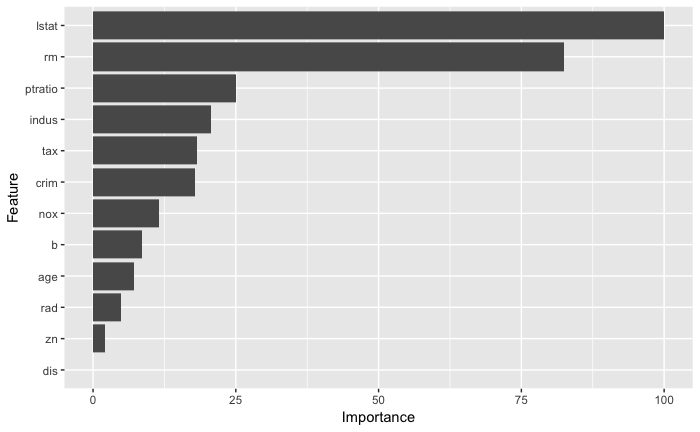

```r
control <- trainControl(method="repeatedcv", number = 10, repeats = 3)
model <- train(medv ~., data=df_boston, method = "knn", trControl = control)
importance <- varImp(model)
ggplot(importance)
```

## Automatic Feature Selection

*TODO* Use and `rfe` to do automatic feature selection. You’ll want to pass in the control provided.

```r
# control using random forest
control <- rfeControl(functions = rfFuncs, method="cv", number=10)
results <- rfe(df_boston[,1:12], df_boston[,13], sizes = c(1:12), rfeControl = control) # this will take AWHILE...
results
```

```
Recursive feature selection

Outer resampling method: Cross-Validated (10 fold)

Resampling performance over subset size:

 Variables  RMSE Rsquared   MAE RMSESD RsquaredSD  MAESD Selected
         1 6.684   0.4969 4.816 0.8764    0.10140 0.4759
         2 4.508   0.7655 3.135 0.9346    0.07328 0.4036
         3 3.711   0.8383 2.684 0.6657    0.05706 0.4060
         4 3.484   0.8629 2.449 0.8273    0.05625 0.3849
         5 3.425   0.8693 2.398 0.9493    0.06445 0.4396
         6 3.114   0.8921 2.212 0.7672    0.03947 0.3598
         7 3.107   0.8933 2.209 0.7840    0.04003 0.3690
         8 3.083   0.8958 2.162 0.8479    0.04256 0.3800
         9 3.025   0.8979 2.129 0.8074    0.04055 0.3608
        10 3.019   0.8995 2.131 0.8156    0.04109 0.3636
        11 3.057   0.8972 2.147 0.8507    0.04308 0.3646
        12 2.985   0.9013 2.119 0.7909    0.03961 0.3541        *

The top 5 variables (out of 12):
   rm, lstat, nox, dis, ptratio
```

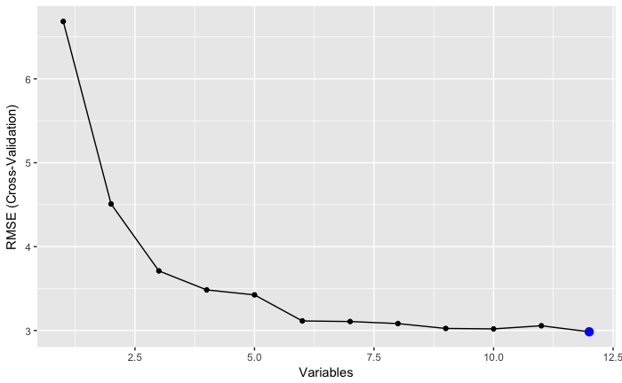

```r
ggplot(results)
```

```r
# chosen features
predictors(results)
```

```
 [1] "rm"      "lstat"   "nox"     "dis"     "ptratio" "crim"    "age"     "tax"     "indus"   "b"       "rad"     "zn"
```

*TODO*: Select the most important features (up to 10) and use only those parameters moving forward

```r
selected_features <- predictors(results)[1:6] #TODO
selected_features
```

```
[1] "rm"      "lstat"   "nox"     "dis"     "ptratio" "crim"
```

# Fitting parameters

Now it’s time to try fitting different models. See more about models here: http://topepo.github.io/caret/available-models.html

*TODO*: Fit a generalized linear model - Use `expand.grid()` to create a dataframe from all combinations of alpha (start with c(0, 0.1, 0.2, 0.4, 0.6, 0.8, 1.0) and adjust accordingrtly) and lambda values 1e-5, 1e-4, … 1

```r
glmnet_grid <- expand.grid(alpha = c(0,  .1,  .2, .4, .6, .8, 1),
                           lambda = c(1e-6, 1e-5, 1e-4, 1e-3, 1e-2, 1e-1,1))
glmnet_ctrl <- trainControl(method = "cv", number = 10)
glmnet_fit <- train(medv ~ ., data = df_boston[, c(selected_features, "medv")],
                    method = "glmnet",
                    preProcess = c("center", "scale"),
                    tuneGrid = glmnet_grid,
                    trControl = glmnet_ctrl)
```

[output not shown]

```r
glmnet_fit
```

```
glmnet

506 samples
  6 predictor

Pre-processing: centered (6), scaled (6)
Resampling: Cross-Validated (10 fold)
Summary of sample sizes: 457, 454, 457, 456, 456, 455, ...
Resampling results across tuning parameters:

  alpha  lambda  RMSE      Rsquared   MAE
  0.0    1e-06   4.933219  0.7195499  3.493755
  0.0    1e-05   4.933219  0.7195499  3.493755
  0.0    1e-04   4.933219  0.7195499  3.493755
  0.0    1e-03   4.933219  0.7195499  3.493755
  0.0    1e-02   4.933219  0.7195499  3.493755
  0.0    1e-01   4.933219  0.7195499  3.493755
  0.0    1e+00   4.949375  0.7193414  3.497779
  0.1    1e-06   4.926422  0.7183406  3.520938
  0.1    1e-05   4.926422  0.7183406  3.520938
  0.1    1e-04   4.926422  0.7183406  3.520938
  0.1    1e-03   4.926422  0.7183406  3.520938
  0.1    1e-02   4.926422  0.7183406  3.520938
  0.1    1e-01   4.925687  0.7185634  3.516134
  0.1    1e+00   4.979534  0.7174239  3.512831
  0.2    1e-06   4.926788  0.7182796  3.521315
  0.2    1e-05   4.926788  0.7182796  3.521315
  0.2    1e-04   4.926788  0.7182796  3.521315
  0.2    1e-03   4.926788  0.7182796  3.521315
  0.2    1e-02   4.926788  0.7182796  3.521315
  0.2    1e-01   4.926615  0.7185123  3.515490
  0.2    1e+00   5.020438  0.7143758  3.535418
  0.4    1e-06   4.927273  0.7182263  3.522061
  0.4    1e-05   4.927273  0.7182263  3.522061
  0.4    1e-04   4.927273  0.7182263  3.522061
  0.4    1e-03   4.927273  0.7182263  3.522061
  0.4    1e-02   4.927273  0.7182263  3.522061
  0.4    1e-01   4.928794  0.7183933  3.514270
  0.4    1e+00   5.140102  0.7036156  3.613827
  0.6    1e-06   4.927509  0.7182170  3.522365
```

[output cut: 8 more lines]

```
  0.8    1e-04   4.927686  0.7181928  3.522566
  0.8    1e-03   4.927686  0.7181928  3.522566
  0.8    1e-02   4.927686  0.7181928  3.522566
  0.8    1e-01   4.935091  0.7179796  3.513233
  0.8    1e+00   5.303721  0.6901486  3.739413
  1.0    1e-06   4.927802  0.7181718  3.522619
  1.0    1e-05   4.927802  0.7181718  3.522619
  1.0    1e-04   4.927802  0.7181718  3.522619
  1.0    1e-03   4.927802  0.7181718  3.522619
  1.0    1e-02   4.927802  0.7181718  3.522619
  1.0    1e-01   4.939177  0.7176863  3.513772
  1.0    1e+00   5.346916  0.6889493  3.768017

RMSE was used to select the optimal model using  the smallest value.
The final values used for the model were alpha = 0.1 and lambda = 0.1.
```

*TODO*: Fit a penalized logistic regression model (plr) with all features (not just the ones we previously selected) to predict if a neighborhood is charles river tract or not (chas).

This model is problematic because the optimal lambda function is the largest one. Not sure what’s happening here…

```r
df_boston_all <- BostonHousing

plr_grid <- expand.grid(lambda = c(1e-6, 1e-5, 1e-4, 1e-3, 1e-2, 1e-1,1, 1e2, 1e3, 1e4, 1e5), cp = c("bic", "aic"))
plr_ctrl <- trainControl(method = "cv", number = 10)
plr_fit <- train(chas ~ ., data = df_boston_all,
                    method = "plr",
                    preProcess = c("center", "scale"),
                    tuneGrid = plr_grid,
                    trControl = plr_ctrl)
plr_fit
```

```
Penalized Logistic Regression

506 samples
 13 predictor
  2 classes: '0', '1'

Pre-processing: centered (13), scaled (13)
Resampling: Cross-Validated (10 fold)
Summary of sample sizes: 456, 455, 456, 456, 456, 455, ...
Resampling results across tuning parameters:

  lambda  cp   Accuracy   Kappa
  1e-06   bic  0.9269351  -0.006185567
  1e-06   aic  0.9269351  -0.006185567
  1e-05   bic  0.9269351  -0.006185567
  1e-05   aic  0.9269351  -0.006185567
  1e-04   bic  0.9269351  -0.006185567
  1e-04   aic  0.9269351  -0.006185567
  1e-03   bic  0.9269351  -0.006185567
  1e-03   aic  0.9269351  -0.006185567
  1e-02   bic  0.9269351  -0.006185567
  1e-02   aic  0.9269351  -0.006185567
  1e-01   bic  0.9269351  -0.006185567
  1e-01   aic  0.9269351  -0.006185567
  1e+00   bic  0.9269351  -0.006185567
  1e+00   aic  0.9269351  -0.006185567
  1e+02   bic  0.9309351   0.000000000
  1e+02   aic  0.9309351   0.000000000
  1e+03   bic  0.9309351   0.000000000
  1e+03   aic  0.9309351   0.000000000
  1e+04   bic  0.9309351   0.000000000
  1e+04   aic  0.9309351   0.000000000
  1e+05   bic  0.9309351   0.000000000
  1e+05   aic  0.9309351   0.000000000

Accuracy was used to select the optimal model using  the largest value.
The final values used for the model were lambda = 1e+05 and cp = bic.
```